# Project 7

Like previous project assignments, please don't forget to submit your .ipynb and .html files to Canvas.

A hospital in Philadelphia is trying to better streamline its operations and plan for the future by reducing the number hospitalizations that could have been prevented. They have approached you, a data scientist, to help predict if patients will develop heart diseases so that healthcare providers have a chance to intervene much earlier. For this task, you have been provided with the Heart dataset, containing a binary outcome 'HD' that indicates the presence of heart disease in 303 patients. There are 13 predictors including 'Age', 'Sex', 'Chol' (a cholesterol measurement), and other heart and lung function measurements.

```python
#Data Wrangling
import numpy as np
import pandas as pd

#Trees
from sklearn import tree
from sklearn.ensemble import BaggingRegressor
from sklearn.ensemble import BaggingClassifier
from sklearn.ensemble import RandomForestClassifier
from sklearn.ensemble import RandomForestRegressor
from sklearn.ensemble import GradientBoostingRegressor

#Preprocessing Packages
from sklearn.model_selection import train_test_split
from sklearn.preprocessing import LabelBinarizer #One hot encoding
from sklearn.pipeline import Pipeline
from sklearn.pipeline import FeatureUnion
from sklearn.base import BaseEstimator, TransformerMixin

#Cross Validation
from sklearn.model_selection import cross_val_score
from sklearn.model_selection import KFold

#Metrics
from sklearn.metrics import mean_squared_error
from sklearn.metrics import confusion_matrix

#Plotting
import seaborn as sns
import matplotlib.pyplot as plt
from IPython.display import Image
import pydotplus
import collections

#Accuracy Measures
from sklearn.metrics import precision_score
from sklearn.metrics import recall_score
from sklearn.metrics import accuracy_score
from sklearn.model_selection import GridSearchCV

#For hyper-parameter tunning
from sklearn.model_selection import GridSearchCV
from sklearn.model_selection import RandomizedSearchCV

#Bootstrap
from sklearn.utils import resample

%matplotlib inline
```

## Getting Set Up

Meet our old friend - PennGrader! Enter your PennKey below (your Penn email prefix).

```python
#PLEASE ENSURE YOUR Penn Key IS ENTERED CORRECTLY. IF NOT, THE AUTOGRADER WON'T KNOW WHO
#TO ASSIGN POINTS TO YOU IN OUR BACKEND

STUDENT_PENN_KEY = "niubide"                  # YOUR PENN-KEY GOES HERE
STUDENT_NAME = "Nicolas Ubide"                # YOUR FULL NAME GOES HERE
```

```python
#Importing PennGrader
import penngrader.grader
grader = penngrader.grader.PennGrader(homework_id = 'ESE305_F2020_HW7', student_id = STUDENT_PENN_KEY)
```

Now we are ready for this project. Before building our models, let's take a look at how the data looks like.

1. Load the Heart data and drop any rows with `NaN/null` values.

```python
#Importing the "hear" CSV
heart = pd.read_csv('Heart.csv')
```

```python
# Drop all rows with NaN/null inplace
heart.dropna(inplace=True)
```

```python
grader.grade(test_case_id = 'test_read_data', answer = heart.shape)
```

```
Correct! You earned 1/1 points. You are a star!

Your submission has been successfully recorded in the gradebook.
```

1. Binarize the 'HD' values such that `No=0` and `Yes=1`. One hot encode categorical features, and set prefixes to original column names. Produce some numerical and graphical summaries of it. Do there appear to be any patterns?

*Hint*: Don't forget to drop original columns after one hot encode.

```python
#Convert HD values to binary
heart['HD'] = [1 if x == "Yes" else 0 for x in heart['HD']]
```

```python
#One-hot encoding categoerical features
dummies = pd.get_dummies(heart[['ChestPain', 'Thal']]) #One Hot encding

# Drop the column with original categorical variables
heart_ = heart.drop(['ChestPain', 'Thal'], axis=1).astype('float64')
heart = pd.concat([heart_, dummies], axis=1)
```

```python
#Producing summary stats
heart.describe()
```

|  | Age | Sex | RestBP | Chol | Fbs | RestECG | MaxHR | ExAng | Oldpeak | Slope | Ca | HD | ChestPain_asymptomatic | ChestPain_nonanginal | ChestPain_nontypical | ChestPain_typical | Thal_fixed | Thal_normal | Thal_reversable |
| --- | --- | --- | --- | --- | --- | --- | --- | --- | --- | --- | --- | --- | --- | --- | --- | --- | --- | --- | --- |
| count | 297.000000 | 297.000000 | 297.000000 | 297.000000 | 297.000000 | 297.000000 | 297.000000 | 297.000000 | 297.000000 | 297.000000 | 297.000000 | 297.000000 | 297.000000 | 297.000000 | 297.000000 | 297.000000 | 297.000000 | 297.000000 | 297.000000 |
| mean | 54.542088 | 0.676768 | 131.693603 | 247.350168 | 0.144781 | 0.996633 | 149.599327 | 0.326599 | 1.055556 | 1.602694 | 0.676768 | 0.461279 | 0.478114 | 0.279461 | 0.164983 | 0.077441 | 0.060606 | 0.552189 | 0.387205 |
| std | 9.049736 | 0.468500 | 17.762806 | 51.997583 | 0.352474 | 0.994914 | 22.941562 | 0.469761 | 1.166123 | 0.618187 | 0.938965 | 0.499340 | 0.500364 | 0.449492 | 0.371792 | 0.267741 | 0.239009 | 0.498108 | 0.487933 |
| min | 29.000000 | 0.000000 | 94.000000 | 126.000000 | 0.000000 | 0.000000 | 71.000000 | 0.000000 | 0.000000 | 1.000000 | 0.000000 | 0.000000 | 0.000000 | 0.000000 | 0.000000 | 0.000000 | 0.000000 | 0.000000 | 0.000000 |
| 25% | 48.000000 | 0.000000 | 120.000000 | 211.000000 | 0.000000 | 0.000000 | 133.000000 | 0.000000 | 0.000000 | 1.000000 | 0.000000 | 0.000000 | 0.000000 | 0.000000 | 0.000000 | 0.000000 | 0.000000 | 0.000000 | 0.000000 |
| 50% | 56.000000 | 1.000000 | 130.000000 | 243.000000 | 0.000000 | 1.000000 | 153.000000 | 0.000000 | 0.800000 | 2.000000 | 0.000000 | 0.000000 | 0.000000 | 0.000000 | 0.000000 | 0.000000 | 0.000000 | 1.000000 | 0.000000 |
| 75% | 61.000000 | 1.000000 | 140.000000 | 276.000000 | 0.000000 | 2.000000 | 166.000000 | 1.000000 | 1.600000 | 2.000000 | 1.000000 | 1.000000 | 1.000000 | 1.000000 | 0.000000 | 0.000000 | 0.000000 | 1.000000 | 1.000000 |
| max | 77.000000 | 1.000000 | 200.000000 | 564.000000 | 1.000000 | 2.000000 | 202.000000 | 1.000000 | 6.200000 | 3.000000 | 3.000000 | 1.000000 | 1.000000 | 1.000000 | 1.000000 | 1.000000 | 1.000000 | 1.000000 | 1.000000 |

```python
grader.grade(test_case_id = 'test_hot_encode', answer = heart)
```

```
Correct! You earned 2/2 points. You are a star!

Your submission has been successfully recorded in the gradebook.
```

1. What is the minimum and maximum ages of the patients in the dataset? Assign this value to the variable `min_age` and `max_age`.

```python
min_age = min(heart["Age"])
max_age = max(heart["Age"])
```

```python
grader.grade(test_case_id = 'test_age', answer = (min_age, max_age))
```

```
Correct! You earned 1.0/1 points. You are a star!

Your submission has been successfully recorded in the gradebook.
```

1. Calculate the pairwise correlations between all the variables. Which predictor has the highest positive correlation with the response variable? Assign this to `highest_corr`.

```python
#Finding highest corr
highest_corr = abs(heart.corr()["HD"]).sort_values(ascending=False)[1:].idxmax()
```

```python
grader.grade(test_case_id = 'test_corr', answer = highest_corr)
```

```
Correct! You earned 1/1 points. You are a star!

Your submission has been successfully recorded in the gradebook.
```

1. Since we are interested in building a predictive model, it is good practice to split the data into training and testing sets. Using `sklearn.model_selection.train_test_split`, divide the data into these sets using a 80/20 split with a `random_state=42`. These training and testing sets will be used for all the following parts.

```python
#Creating X vectors and y response variable
X = heart.drop(columns=["HD"])
y = heart["HD"]


#Splitting the data
X_train, X_test, y_train, y_test = train_test_split(X, y, test_size=0.2, random_state=42)
```

```python
grader.grade(test_case_id = 'test_split', answer = (X_train, y_train))
```

```
Correct! You earned 2/2 points. You are a star!

Your submission has been successfully recorded in the gradebook.
```

## 7. Part A: Decision Tree

1. Using all predictor variables, train a base classification tree to predict the response variable. Use `sklearn.tree.DecisionTreeClassifier` and set `random_state=42`.

*Hint*: here is the link for the documentation of [sklearn.tree.DecisionTreeClassifier](https://scikit-learn.org/stable/modules/generated/sklearn.tree.DecisionTreeClassifier.html).

```python
#Creating the base classification tree
clf = tree.DecisionTreeClassifier(random_state=42)
X = X_train.values
y = y_train.values
fit1 = clf.fit(X, y)
```

```python
grader.grade(test_case_id = 'test_dt', answer = (clf.n_classes_, clf.n_features_))
```

```
Correct! You earned 1.0/1 points. You are a star!

Your submission has been successfully recorded in the gradebook.
```

1. Plot the decision tree using the `Graphviz` package. Do you notice anything interesting?

*Hint*: Here is a great reference on how to use [Graphviz](https://pythonprogramminglanguage.com/decision-tree-visual-example/) to visualize your decision tree.

```python
#List of features
data_feature_names = X_train.columns.tolist()

# Visualize data
dot_data = tree.export_graphviz(clf,
                                feature_names=data_feature_names,
                                out_file=None,
                                filled=True,
                                rounded=True)

graph = pydotplus.graph_from_dot_data(dot_data)

img = Image(graph.create_png())
```

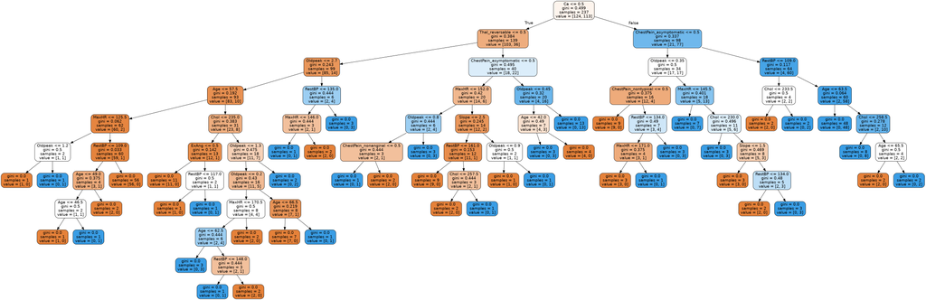

```python
#Visualize:
img
```

```python
grader.grade(test_case_id = 'test_image', answer = (str(type(img))))
```

```
Correct! You earned 1/1 points. You are a star!

Your submission has been successfully recorded in the gradebook.
```

1. Evaluate your base model on the test set by calculating the precision, recall and accuracy. Assign these values to `dt_precision`, `dt_recall` and `dt_accuracy` respectively. Name your model `dt`.

*Hint*: A useful resource if you need a refresher of these terms is [here](https://en.wikipedia.org/wiki/Precision_and_recall).

```python
#Finding the confusion matrix in order to get the precision and the recal
conf_matrix = confusion_matrix(y_test, fit1.predict(X_test))

#Assigning the values
dt_precision = conf_matrix[0][0] / sum(conf_matrix[0])
dt_recall = conf_matrix[0][0] / (conf_matrix[0][0] + conf_matrix[1][0])
dt_accuracy = clf.score(X_test, y_test)
```

```python
grader.grade(test_case_id = 'test_dt_score', answer = (dt_precision, dt_recall, dt_accuracy))
```

```
Correct! You earned 1.5/1.5 points. You are a star!

Your submission has been successfully recorded in the gradebook.
```

1. Which hyperparameter should we tune when building a decision tree? Select all that applies:

A. Tree depth

B. Number of estimators

C. Number of output classes

D. Percent of samples trained

```python
#Declaring the answers
answers = ['A']
```

```python
grader.grade(test_case_id = 'test_dt_tune', answer = answers)
```

```
Correct! You earned 0.5/0.5 points. You are a star!

Your submission has been successfully recorded in the gradebook.
```

1. Tune the hyperparameters of your model and evaluate this tuned model by calculating the precision, recall and accuracy on the test set. Assign these calculated values to `dt_tuned_precision`, `dt_tuned_recall` and `dt_tuned_accuracy` respectively. *Hint*: 1. refer to the documentation to determine what can be tuned. 2. For each tuned parameter, search through range between 3 and 21 to find the best performing parameters.

```python
# Enter your code here
precision_list = []
recall_list = []
accuracy_list = []

for i in range(3,21):

    #Creating the tree classifier
    clf = tree.DecisionTreeClassifier(max_depth = i, random_state = 42)
    fit = clf.fit(X_train, y_train)

    #Generating the current conf_matrix
    conf_matrix = confusion_matrix(y_test,clf.predict(X_test))

    #Assigning the values
    precision = conf_matrix[0][0] / sum(conf_matrix[0])
    recall = conf_matrix[0][0] / (conf_matrix[0][0] + conf_matrix[1][0])
    accuracy = clf.score(X_test, y_test)

    #Appending
    precision_list.append(precision)
    recall_list.append(recall)
    accuracy_list.append(accuracy)
```

```python
#Selecting the best of each list
dt_tuned_precision = min(precision_list)
dt_tuned_recall = min(recall_list)
dt_tuned_accuracy = max(accuracy_list)
```

```python
grader.grade(test_case_id = 'test_dt_tuned', answer = (dt_tuned_precision, dt_tuned_recall, dt_tuned_accuracy))
```

```
Correct! You earned 1.5/1.5 points. You are a star!

Your submission has been successfully recorded in the gradebook.
```

## 8. Part B: Bagging

1. Using all predictor variables, train a base model to predict the response variable. Use `sklearn.ensemble.BaggingClassifier` and set `random_state=42`. Name your model as `bag`.

```python
#Creating the base classification tree
clf_bagging = BaggingClassifier(random_state=42)
bag = clf_bagging.fit(X_train.values, y_train.values)
```

```python
grader.grade(test_case_id = 'test_bag', answer = bag.estimators_samples_)
```

```
Correct! You earned 0.5/0.5 points. You are a star!

Your submission has been successfully recorded in the gradebook.
```

1. Evaluate your base model on the test set by calculating the precision, recall and accuracy. Assign these values to `bag_precision`, `bag_recall` and `bag_accuracy` respectively.

```python
#Finding the confusion matrix in order to get the precision and the recal
conf_matrix = confusion_matrix(y_test, bag.predict(X_test))

#Assigning the values
bag_precision = conf_matrix[0][0] / sum(conf_matrix[0])
bag_recall = conf_matrix[0][0] / (conf_matrix[0][0] + conf_matrix[1][0])
bag_accuracy = clf.score(X_test, y_test)
```

```python
grader.grade(test_case_id = 'test_bag_score', answer = (bag_precision, bag_recall, bag_accuracy))
```

```
Correct! You earned 1.0/1 points. You are a star!

Your submission has been successfully recorded in the gradebook.
```

1. Do **not** modify `base_classifier`. Tune the hyperparameters of your model and evaluate this tuned model by calculating the precision, recall and accuracy on the test set. Assign these calculated values to `bag_tuned_precision`, `bag_tuned_recall` and `bag_tuned_accuracy` respectively. Store your best performing estimators to `bag_best_param` as a dictionary ('tuned estimator' : number). *Hint*: For each tuned parameters, set searching space to all integers between range 10 and 50.

```python
#Storing accuracy scores in a list
bag_accuracy_list = []

for i in np.arange(10,50):

    #Re-fiting the original model with the n_esimtators hyperparameter re-callibrated to the value of (i)
    bag.set_params(n_estimators = i)
    bag_updated = bag.fit(X_train, y_train)

    #Calculating the accuracy score
    accuracy = bag_updated.score(X_test, y_test)

    #Storing the accuracy score and the value (i)
    bag_accuracy_list.append([accuracy , i])
```

```python
#Finding the most accurate value
bag_best_param_value = max(bag_accuracy_list)[1]

#Storing it in the dictionary
bag_best_param = {'n_estimators': bag_best_param_value}
```

```python
#Creatting an optimized model using the best_param we found above
clf_bagging = BaggingClassifier(n_estimators = bag_best_param_value, random_state=42)
bag_optimized = clf_bagging.fit(X_train.values, y_train.values)

#Finding the precision, recall, and accuracy of the optimized model
bag_tuned_precision = precision_score(y_test, bag_optimized.predict(X_test))
bag_tuned_recall = recall_score(y_test, bag_optimized.predict(X_test))
bag_tuned_accuracy = accuracy_score(y_test, bag_optimized.predict(X_test))
```

```python
grader.grade(test_case_id = 'test_bag_tuned', answer = (bag_tuned_precision, bag_tuned_recall, bag_tuned_accuracy))
```

```
Correct! You earned 1/1 points. You are a star!

Your submission has been successfully recorded in the gradebook.
```

```python
grader.grade(test_case_id = 'test_bag_best', answer = bag_best_param)
```

```
Correct! You earned 1/1 points. You are a star!

Your submission has been successfully recorded in the gradebook.
```

## 9. Part C: Random Forest

1. Using all predictor variables, train a base random forest to predict the response variable. Use `sklearn.ensemble.RandomForestClassifier` and set `random_state=42`. Name your model `rf`.

```python
#Creating the base classification tree
clf_rf = RandomForestClassifier(random_state=42)
rf = clf_rf.fit(X_train.values, y_train.values)
```

```python
grader.grade(test_case_id = 'test_rf', answer = rf.n_estimators)
```

```
Correct! You earned 0.5/0.5 points. You are a star!

Your submission has been successfully recorded in the gradebook.
```

1. Evaluate your base model on the test set by calculating the precision, recall and accuracy. Assign these values to `rf_precision`, `rf_recall` and `rf_accuracy` respectively.

```python
#Finding the confusion matrix in order to get the precision and the recal
conf_matrix = confusion_matrix(y_test, rf.predict(X_test))

#Assigning the values
rf_precision = conf_matrix[0][0] / sum(conf_matrix[0])
rf_recall = conf_matrix[0][0] / (conf_matrix[0][0] + conf_matrix[1][0])
rf_accuracy = clf.score(X_test, y_test)
```

```python
grader.grade(test_case_id = 'test_rf_score', answer = (rf_precision, rf_recall, rf_accuracy))
```

```
Correct! You earned 0.5/0.5 points. You are a star!

Your submission has been successfully recorded in the gradebook.
```

1. Tune the hyperparameters of your model and evaluate this tuned model by calculating the precision, recall and accuracy on the test set. Assign these calculated values to `rf_tuned_precision`, `rf_tuned_recall` and `rf_tuned_accuracy` respectively. Store your best-performing parameters to `rf_tuned`. Also don't forget to set `random_state=42`.

*Hint*:

1. In this question, we would like to tune only the parameters determining the depth of a tree and the number of trees. But beware that you can also adjust the maximum number of features considered for each tree(max_features), the minimum number of data points placed in a node before the node is split(min_samples_split), the minimum number of data points allowed in a leaf node(min_samples_leaf), and bootstrap option. Refer to [sklearn.RandomForestClassifier](https://scikit-learn.org/stable/modules/generated/sklearn.ensemble.RandomForestClassifier.html) for a complete list.
2. In this question, your parameter search space is (3,21) for tree depth, (10,30) for number of trees.

```python
#Defining the search space
search_space = (3,21)

#Storing the names of the hyperparameters we want to optimize in a dictionary:
params = {'max_depth': search_space, 'n_estimators': search_space}

#Using the RandomizedSearchCV function to optimize the specified paramters
rs = RandomizedSearchCV(RandomForestClassifier(random_state=42), param_distributions = params, scoring = 'accuracy')

#Fitting the model
model = rs.fit(X_train, y_train)

#Finding precision, recall, and accuracy scores
rf_tuned_precision = precision_score(y_test, model.predict(X_test))
rf_tuned_recall = recall_score(y_test, model.predict(X_test))
rf_tuned_accuracy = accuracy_score(y_test, model.predict(X_test))

#Storing best performing parameters:
rf_tuned = rs.best_params_
```

```python
grader.grade(test_case_id = 'test_rf_tuned', answer = (rf_tuned_precision, rf_tuned_recall, rf_tuned_accuracy))
```

```
Correct! You earned 1/1 points. You are a star!

Your submission has been successfully recorded in the gradebook.
```

```python
grader.grade(test_case_id = 'test_rf_tuned_params', answer = rf_tuned)
```

```
Correct! You earned 1/1 points. You are a star!

Your submission has been successfully recorded in the gradebook.
```

1. Of the 3 base models that you trained, which model achieved the highest test accuracy?

A. Decision Tree

B. Bagging

C. Random Forest

```python
#Declaring answer
choice = ['C']
```

```python
grader.grade(test_case_id = 'test_base', answer = choice)
```

```
Correct! You earned 0.5/0.5 points. You are a star!

Your submission has been successfully recorded in the gradebook.
```

1. Of the 3 models in which you tuned the parameters, which model achieved the highest test accuracy?

A. Decision Tree

B. Bagging

C. Random Forest

```python
#Declaring answer
choice = ['c']
```

```python
grader.grade(test_case_id = 'test_tuned', answer = choice)
```

```
Correct! You earned 0.5/0.5 points. You are a star!

Your submission has been successfully recorded in the gradebook.
```

1. *Food for thought (ungraded but interesting to think about)*: In this project, we asked you to pick the model with the highest test accuracy. For this task, do you think that accuracy is the best metric to use, or would precision, recall or even the F1-score be better?